# Heart Disease Analysis

Mohammad Hamza Piracha, Ayesha Saif

2024-11-10

## Initial Analysis: Model Fitting and Interpretation

Response Variable: HeartDisease (Binary - 0 = No, 1 = Yes)

Predictor Variables:

Continuous Variables: Age, RestingBP & Cholesterol.

Categorical Variables: Sex & ChestPainType.

Model Specification: Logistic Regression Model For Binary Response.

```r
# Libraries
library(tidyverse)
library(caret)
library(car)
```

```r
#library(MASS)
library(ggplot2)

# Load Data
data <- read.csv("heart.csv")

# Preprocessing Categorical Variables
data$Sex <- as.factor(data$Sex)
data$ChestPainType <- as.factor(data$ChestPainType)
```

Exploring data

```r
# Check the shape of the data
print(paste("Shape of data: ", dim(data)))
```

```
## [1] "Shape of data:  918" "Shape of data:  12"
```

```r
# Check for missing values in each column
print(paste("Missing values in data: ", colSums(is.na(data)))) # Returns a count of NA values for each column
```

```
##  [1] "Missing values in data:  0" "Missing values in data:  0"
##  [3] "Missing values in data:  0" "Missing values in data:  0"
##  [5] "Missing values in data:  0" "Missing values in data:  0"
##  [7] "Missing values in data:  0" "Missing values in data:  0"
##  [9] "Missing values in data:  0" "Missing values in data:  0"
## [11] "Missing values in data:  0" "Missing values in data:  0"
```

```r
# Check data types of each column
print(paste("Data types of columns: "))
```

```
## [1] "Data types of columns: "
```

```r
 str(data)
```

```
## 'data.frame':    918 obs. of  12 variables:
##  $ Age           : int  40 49 37 48 54 39 45 54 37 48 ...
##  $ Sex           : Factor w/ 2 levels "F","M": 2 1 2 1 2 2 1 2 2 1 ...
##  $ ChestPainType : Factor w/ 4 levels "ASY","ATA","NAP",..: 2 3 2 1 3 3 2 2 1 2 ...
##  $ RestingBP     : int  140 160 130 138 150 120 130 110 140 120 ...
##  $ Cholesterol   : int  289 180 283 214 195 339 237 208 207 284 ...
##  $ FastingBS     : int  0 0 0 0 0 0 0 0 0 0 ...
##  $ RestingECG    : chr  "Normal" "Normal" "ST" "Normal" ...
##  $ MaxHR         : int  172 156 98 108 122 170 170 142 130 120 ...
##  $ ExerciseAngina: chr  "N" "N" "N" "Y" ...
##  $ Oldpeak       : num  0 1 0 1.5 0 0 0 0 1.5 0 ...
##  $ ST_Slope      : chr  "Up" "Flat" "Up" "Flat" ...
##  $ HeartDisease  : int  0 1 0 1 0 0 0 0 1 0 ...
```

For logistic regression, we focus on Age, RestingBP, Cholesterol, Sex, and ChestPainType. These variables are correctly formatted: Age, RestingBP, and Cholesterol are numeric, and Sex and ChestPainType are factors. Placeholder values in Cholesterol will be imputed as needed. This data is now ready for visualization and analysis.

To better understand the distributions and identify potential outliers, we proceed with plotting histograms and boxplots for key variables. These visualizations will help us assess normality, detect any skewness, and decide if transformations or additional imputation steps are necessary to ensure the dataset is well-prepared for logistic regression analysis.

```r
library(gridExtra)
```

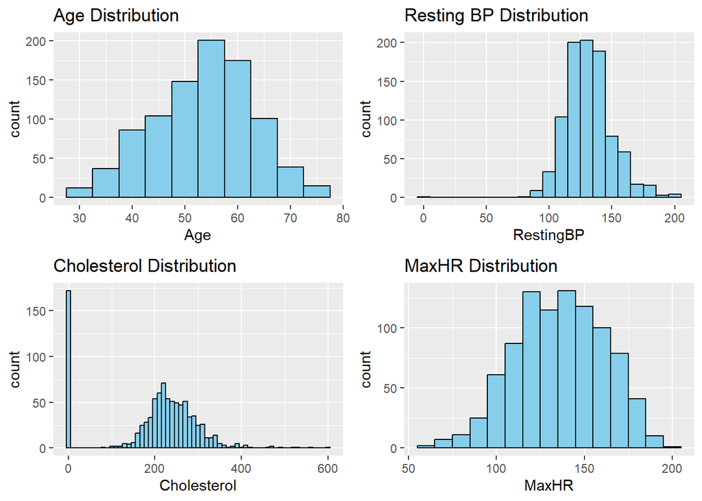

```r
# Plot histograms to visualize distributions
p1 <- ggplot(data, aes(x=Age)) + geom_histogram(binwidth=5, fill="skyblue", color="black") + ggtitle("Age Distribution")
p2 <- ggplot(data, aes(x=RestingBP)) + geom_histogram(binwidth=10, fill="skyblue", color="black") + ggtitle("Resting BP Distribution")
p3 <- ggplot(data, aes(x=Cholesterol)) + geom_histogram(binwidth=10, fill="skyblue", color="black") + ggtitle("Cholesterol Distribution")
p4 <- ggplot(data, aes(x=MaxHR)) + geom_histogram(binwidth=10, fill="skyblue", color="black") + ggtitle("MaxHR Distribution")

# Arrange plots
grid.arrange(p1, p2, p3, p4, ncol=2)
```

Age, RestingBP, and MaxHR: These distributions appear reasonably normal, which is a positive sign, as many regression models (like logistic regression) assume normality of predictors.

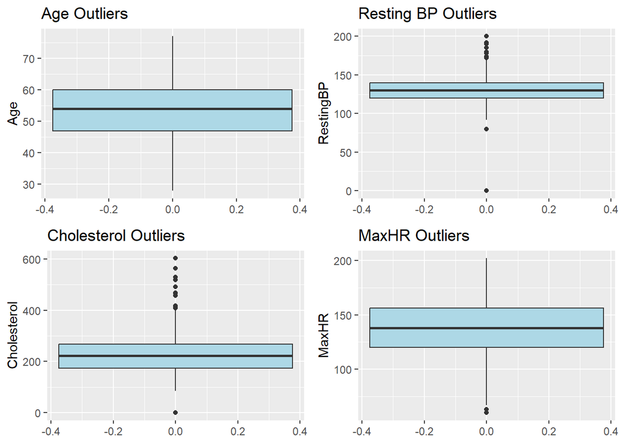

```r
p5 <- ggplot(data, aes(y=Age)) + geom_boxplot(fill="lightblue") + ggtitle("Age Outliers")
p6 <- ggplot(data, aes(y=RestingBP)) + geom_boxplot(fill="lightblue") + ggtitle("Resting BP Outliers")
p7 <- ggplot(data, aes(y=Cholesterol)) + geom_boxplot(fill="lightblue") + ggtitle("Cholesterol Outliers")
p8 <- ggplot(data, aes(y=MaxHR)) + geom_boxplot(fill="lightblue") + ggtitle("MaxHR Outliers")

grid.arrange(p5, p6, p7, p8, ncol=2)
```

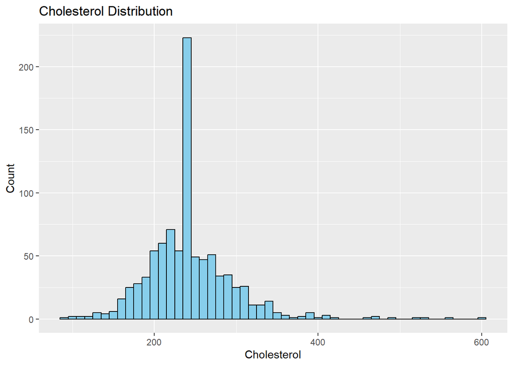

```r
data_copy1 <- data
# Create a missing indicator variable
data_copy1$Cholesterol_Missing <- ifelse(data_copy1$Cholesterol == 0, 1, 0)

# Replace 0s in Cholesterol with the mean of the non-zero values
data_copy1$Cholesterol[data_copy1$Cholesterol == 0] <- mean(data_copy1$Cholesterol[data_copy1$Cholesterol != 0], na.rm = TRUE)

p_cholesterol <- ggplot(data_copy1, aes(x = Cholesterol)) +
                 geom_histogram(binwidth = 10, fill = "skyblue", color = "black") +
                 ggtitle("Cholesterol Distribution") +
                 xlab("Cholesterol") +
                 ylab("Count")

# Display the plot
print(p_cholesterol)
```

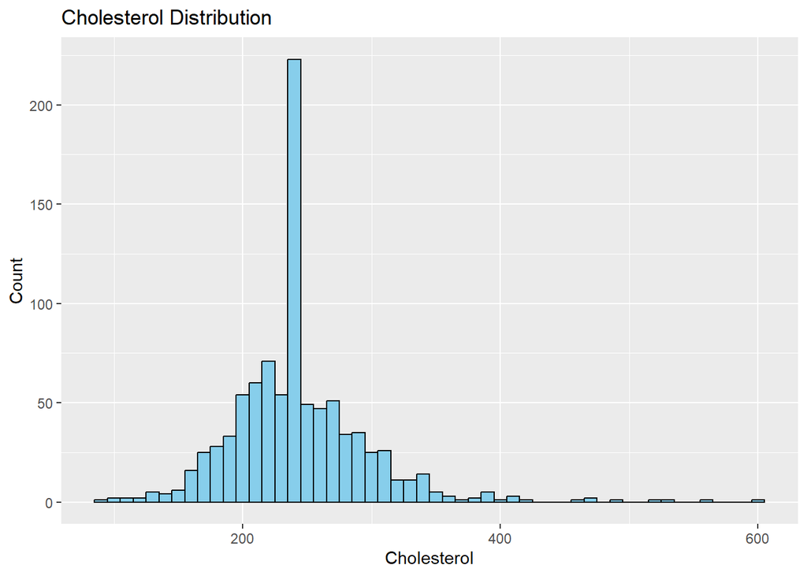

```r
data_copy2 <- data

data_copy2$Cholesterol_Missing <- ifelse(data_copy2$Cholesterol == 0, 1, 0)
# Replace 0s in Cholesterol with the median of the non-zero values
data_copy2$Cholesterol[data_copy2$Cholesterol == 0] <- median(data_copy2$Cholesterol[data_copy2$Cholesterol != 0], na.rm = TRUE)
p_cholesterol <- ggplot(data_copy2, aes(x = Cholesterol)) +
                 geom_histogram(binwidth = 10, fill = "skyblue", color = "black") +
                 ggtitle("Cholesterol Distribution") +
                 xlab("Cholesterol") +
                 ylab("Count")

# Display the plot
print(p_cholesterol)
```

This outcome suggests that directly replacing zeros with either the mean or median might not be ideal for this dataset, as both methods result in an artificial concentration of values at the imputed point.

```r
library(mice)
```

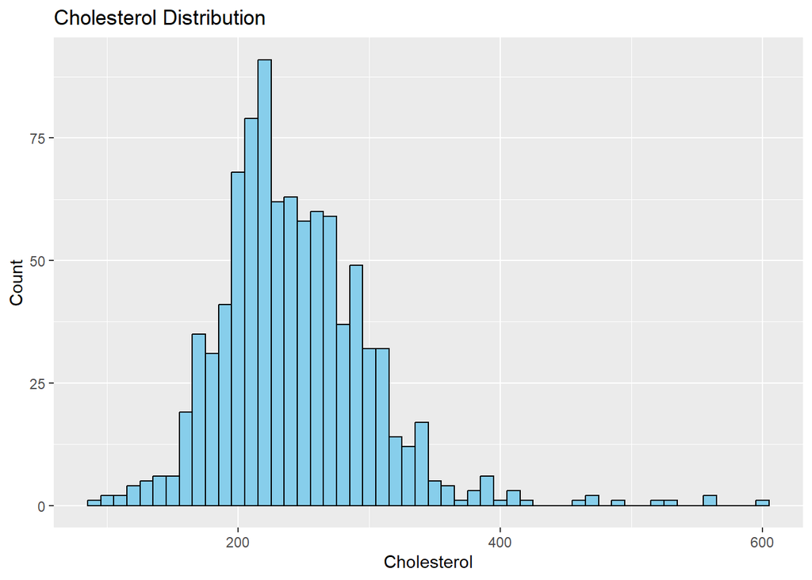

```r
library(ggplot2)

# Step 1: Replace 0 values in Cholesterol with NA
data$Cholesterol[data$Cholesterol == 0] <- NA

# Step 2: Apply Multiple Imputation using Predictive Mean Matching (pmm)
imputed_data <- mice(data, m = 5, method = 'pmm', seed = 123)  # 'm = 5' creates 5 imputed datasets
# Step 3: Complete the dataset with imputed values
data <- complete(imputed_data)
# Plot histograms to visualize distributions
p_cholesterol <- ggplot(data, aes(x = Cholesterol)) +
                 geom_histogram(binwidth = 10, fill = "skyblue", color = "black") +
                 ggtitle("Cholesterol Distribution") +
                 xlab("Cholesterol") +
                 ylab("Count")

# Display the plot
print(p_cholesterol)
```

To address missing values in Cholesterol, we used Multiple Imputation by Chained Equations (MICE) with predictive mean matching, ensuring a realistic distribution without artificially concentrating values around the mean or median. After imputation, Cholesterol displayed slight positive skewness. However, logistic regression is robust to mild skewness in predictors, so we proceeded without further transformations, preserving the variable’s original scale for clearer interpretation.

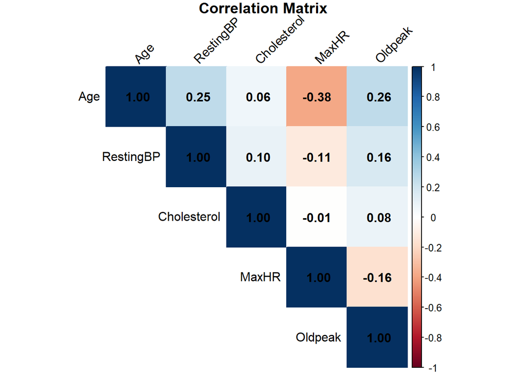

```r
library(dplyr)
library(corrplot)
# Calculate correlation for numeric variables
numeric_data <- data %>% dplyr::select(Age, RestingBP, Cholesterol, MaxHR, Oldpeak)
cor_matrix <- cor(numeric_data, use="complete.obs")

# Plot correlation matrix
corrplot(cor_matrix, method="color", type="upper", addCoef.col = "black",
         tl.col="black", tl.srt=45, title="Correlation Matrix", mar=c(0,0,1,0))
```

APPLYING MODEL

```r
# Fitting Logistic Model
logistic <- glm(HeartDisease ~ Age + RestingBP + Cholesterol + Sex + ChestPainType, data = data, family = binomial)

# Summary For Statistical Significance & Interpretation
summary(logistic)
```

```
##
## Call:
## glm(formula = HeartDisease ~ Age + RestingBP + Cholesterol +
##     Sex + ChestPainType, family = binomial, data = data)
##
## Coefficients:
##                   Estimate Std. Error z value Pr(>|z|)
## (Intercept)      -4.585813   0.822028  -5.579 2.42e-08 ***
## Age               0.054065   0.009662   5.595 2.20e-08 ***
## RestingBP         0.005595   0.004635   1.207   0.2274
## Cholesterol       0.003860   0.001511   2.555   0.0106 *
## SexM              1.622968   0.221694   7.321 2.47e-13 ***
## ChestPainTypeATA -2.921102   0.258378 -11.306  < 2e-16 ***
## ChestPainTypeNAP -1.878138   0.197823  -9.494  < 2e-16 ***
## ChestPainTypeTA  -1.650991   0.346288  -4.768 1.86e-06 ***
## ---
## Signif. codes:  0 '***' 0.001 '**' 0.01 '*' 0.05 '.' 0.1 ' ' 1
##
## (Dispersion parameter for binomial family taken to be 1)
##
##     Null deviance: 1262.14  on 917  degrees of freedom
## Residual deviance:  873.15  on 910  degrees of freedom
## AIC: 889.15
##
## Number of Fisher Scoring iterations: 5
```

Statistical Significance and Interpretation:

Interpretation of the Regression Coefficients: The coefficient for Age is 0.0541, meaning that for each additional year of age, the log-odds of heart disease increase by 0.0541. RestingBP has a coefficient of 0.0056, suggesting a very small increase in risk with higher resting blood pressure, though this relationship is not statistically significant. Cholesterol has a positive coefficient of 0.0039, indicating that for each unit increase in cholesterol, the log-odds of heart disease increase by 0.0039, reflecting a slight risk increase. The coefficient for Sex (Male) is 1.6230, showing that males have significantly higher log-odds of developing heart disease compared to females. Regarding chest pain types, the coefficients for ATA (-2.9211), NAP (-1.8781), and TA (-1.6510) all indicate reduced log-odds of heart disease compared to the baseline, with ATA having the largest negative impact.

Goodness of Fit: The null deviance of 1262.14 indicates the total variability in the response variable when no predictors are included in the model. The residual deviance of 873.15 shows a significant reduction, meaning that the predictors collectively explain a substantial portion of the variability in heart disease outcomes. The AIC of 889.15 provides a measure of model quality, with lower values indicating a better fit. While there is room for improvement, the significant reduction in deviance and the highly significant predictors suggest that the model adequately captures the relationships between the included variables and heart disease risk.

## Regression Diagnostics: Model Assumptions and Issues

Autocorrelation Check:

```r
library(lmtest)
dwtest(logistic)
```

```
##
##  Durbin-Watson test
##
## data:  logistic
## DW = 2.0573, p-value = 0.8023
## alternative hypothesis: true autocorrelation is greater than 0
```

The Durbin-Watson test gives a value of 2.0573, which is very close to 2, indicating little to no autocorrelation. The p-value of 0.8023 suggests that we fail to reject the null hypothesis of no autocorrelation. Thus, the residuals are uncorrelated, and there is no evidence of autocorrelation in the model.

Heteroscedasticity Check:

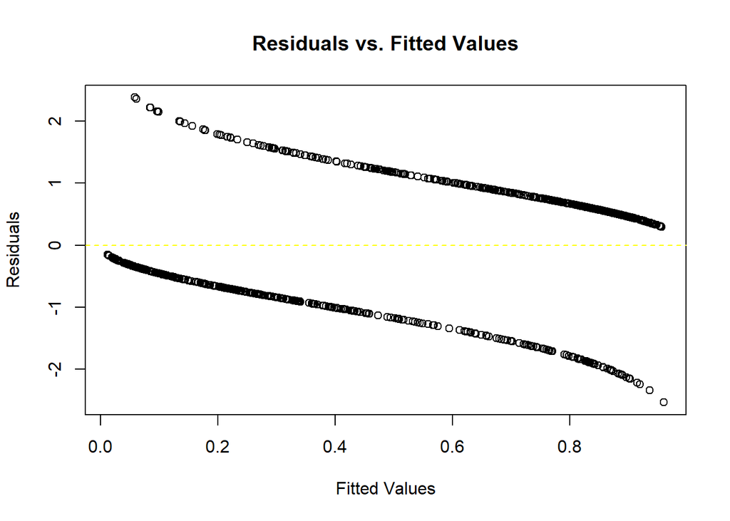

```r
plot(logistic$fitted.values, residuals(logistic), main = "Residuals vs. Fitted Values", xlab = "Fitted Values", ylab = "Residuals")
abline(h = 0, col = "yellow", lty = 2)
```

Multidisciplinary Check:

```r
vif(logistic)
```

```
##                   GVIF Df GVIF^(1/(2*Df))
## Age           1.085599  1        1.041921
## RestingBP     1.077800  1        1.038171
## Cholesterol   1.049126  1        1.024269
## Sex           1.057412  1        1.028305
## ChestPainType 1.033991  3        1.005587
```

The Generalized Variance Inflation Factor values are all close to 1, which is great news. This tells us that our predictors aren’t too closely related, and there’s no problematic multidisciplinary. In simple terms, each variable is contributing its own unique information to the model, so our coefficient estimates are stable and reliable.

Influential Points Check:

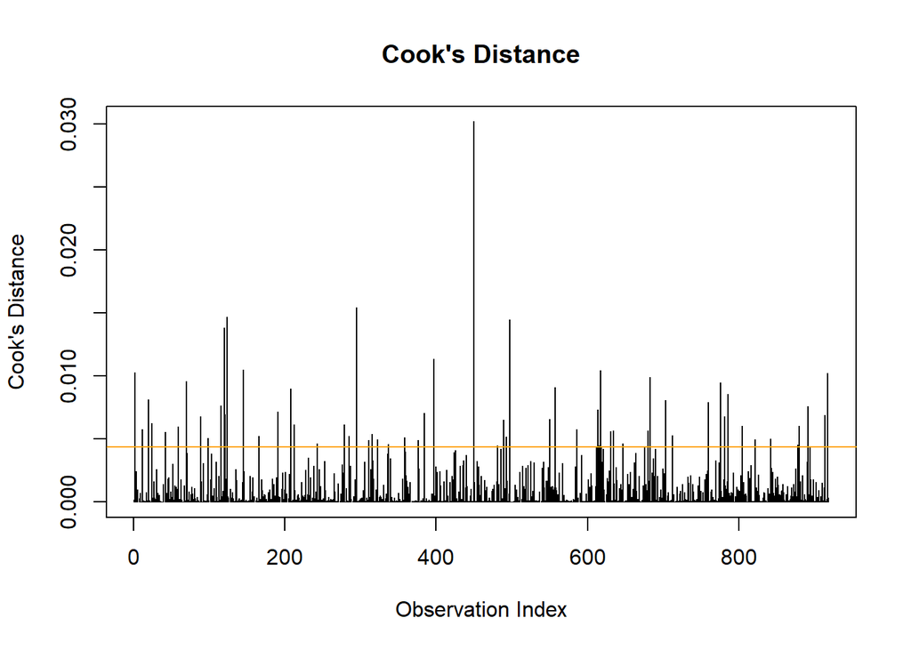

```r
# Cook's Distance and leverage values
cooksd <- cooks.distance(logistic)
plot(cooksd, type = "h", main = "Cook's Distance", ylab = "Cook's Distance", xlab = "Observation Index")
abline(h = 4/length(cooksd), col = "orange")
```

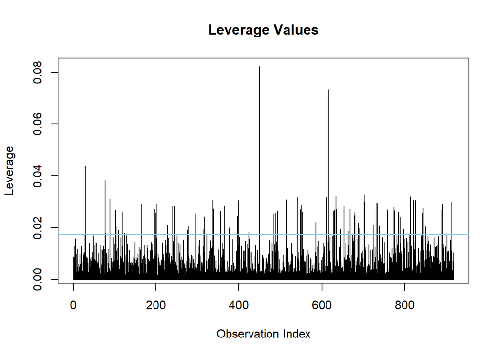

```r
# Leverage values
lev <- hatvalues(logistic)
plot(lev, type = "h", main = "Leverage Values", ylab = "Leverage", xlab = "Observation Index")
abline(h = 2 * mean(lev), col = "skyblue")
```

The Cook’s Distance and leverage plots reveal that there are some data points standing out with higher values, indicating they could be influential. These points have the potential to significantly impact our model’s results, making the estimates less reliable if we don’t handle them carefully.

## Remediation: Addressing Model Issues

Remediating Heteroscedasticity with a Logarithmic Transformation: To deal with the varying spread of our residuals, we’ll apply a log transformation which can help even out the variance, making our model’s predictions more reliable and the statistical tests more accurate.

```r
# Log Transform on RestingBP Predictor
data$LogRestingBP <- log1p(data$RestingBP)

# Fitting The Log Transformed Model
logtrans<- glm(HeartDisease ~ Age + LogRestingBP + Cholesterol + Sex + ChestPainType,family = binomial, data = data)

# Summary Of Log Transformed Model
summary(logtrans)
```

```
##
## Call:
## glm(formula = HeartDisease ~ Age + LogRestingBP + Cholesterol +
##     Sex + ChestPainType, family = binomial, data = data)
##
## Coefficients:
##                   Estimate Std. Error z value Pr(>|z|)
## (Intercept)      -3.790021   1.752264  -2.163  0.03055 *
## Age               0.057093   0.009501   6.009 1.87e-09 ***
## LogRestingBP     -0.051109   0.347884  -0.147  0.88320
## Cholesterol       0.004019   0.001507   2.667  0.00765 **
## SexM              1.613437   0.220856   7.305 2.77e-13 ***
## ChestPainTypeATA -2.910020   0.257690 -11.293  < 2e-16 ***
## ChestPainTypeNAP -1.884359   0.198044  -9.515  < 2e-16 ***
## ChestPainTypeTA  -1.630185   0.345144  -4.723 2.32e-06 ***
## ---
## Signif. codes:  0 '***' 0.001 '**' 0.01 '*' 0.05 '.' 0.1 ' ' 1
##
## (Dispersion parameter for binomial family taken to be 1)
##
##     Null deviance: 1262.1  on 917  degrees of freedom
## Residual deviance:  874.6  on 910  degrees of freedom
## AIC: 890.6
##
## Number of Fisher Scoring iterations: 4
```

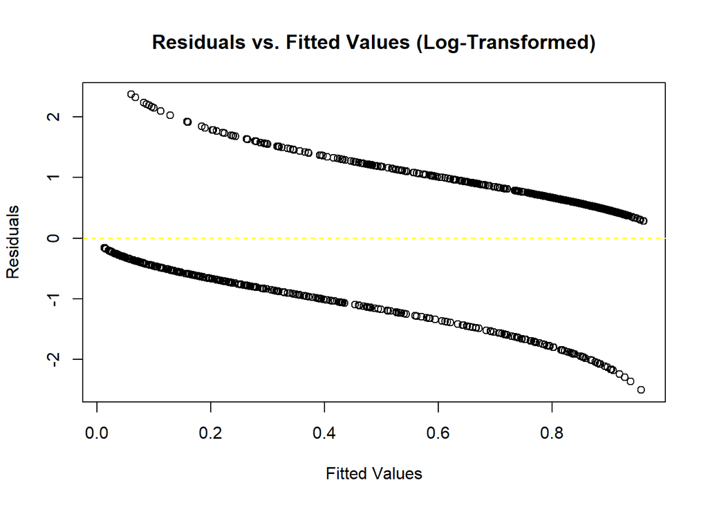

```r
# Plot For Heteroscedasticity check
plot(logtrans$fitted.values, residuals(logtrans), main = "Residuals vs. Fitted Values (Log-Transformed)", xlab = "Fitted Values", ylab = "Residuals")
abline(h = 0, col = "yellow", lty = 2)
```

The log transformation on RestingBP was applied to address the spread of residuals and resolve issues of inconsistent variance. However, this transformation did not make RestingBP a significant predictor in the model, as indicated by its p-value of 0.8832, meaning it had little to no impact on predicting heart disease. In contrast, variables such as Age, Cholesterol, and Sex Male continued to demonstrate strong, meaningful relationships with heart disease, with highly significant p-values of 1.87 x 10^-9, 0.00765, and 2.77 x 10^-13, respectively. Additionally, the categorical variable Chest Pain Type showed consistent and significant effects across its levels, particularly ATA, which reduced the risk substantially.

The overall model fit, measured by residual deviance 874.6 and AIC 890.6, showed no significant improvement after the transformation. Removal of influential points based on Cook’s Distance and leverage values may further refine the model, potentially enhancing its predictive reliability and interpretability.

```r
# Cook's Distance & Leverage Values
cooksd <- cooks.distance(logistic)
lev <- hatvalues(logistic)

# Threshold
cookst <- 4 / length(cooksd)
levt <- 2 * mean(lev)

# Influential Points
ip <- which(cooksd > cookst | lev > levt)
ipr <- data[-ip, ]

# Fitting The Log Model
iprm <- glm(HeartDisease ~ Age + LogRestingBP + Cholesterol + Sex + ChestPainType, family = binomial, data = ipr)

# Summary Of Log Model
summary(iprm)
```

```
##
## Call:
## glm(formula = HeartDisease ~ Age + LogRestingBP + Cholesterol +
##     Sex + ChestPainType, family = binomial, data = ipr)
##
## Coefficients:
##                    Estimate Std. Error z value Pr(>|z|)
## (Intercept)      -13.984710   4.426051  -3.160  0.00158 **
## Age                0.080335   0.013002   6.179 6.47e-10 ***
## LogRestingBP       1.568670   0.915005   1.714  0.08646 .
## Cholesterol        0.006694   0.002200   3.043  0.00234 **
## SexM               2.304371   0.309690   7.441 1.00e-13 ***
## ChestPainTypeATA  -4.881842   0.535535  -9.116  < 2e-16 ***
## ChestPainTypeNAP  -2.201719   0.227419  -9.681  < 2e-16 ***
## ChestPainTypeTA  -12.501349 504.935673  -0.025  0.98025
## ---
## Signif. codes:  0 '***' 0.001 '**' 0.01 '*' 0.05 '.' 0.1 ' ' 1
##
## (Dispersion parameter for binomial family taken to be 1)
##
##     Null deviance: 1097.82  on 797  degrees of freedom
## Residual deviance:  584.14  on 790  degrees of freedom
## AIC: 600.14
##
## Number of Fisher Scoring iterations: 13
```

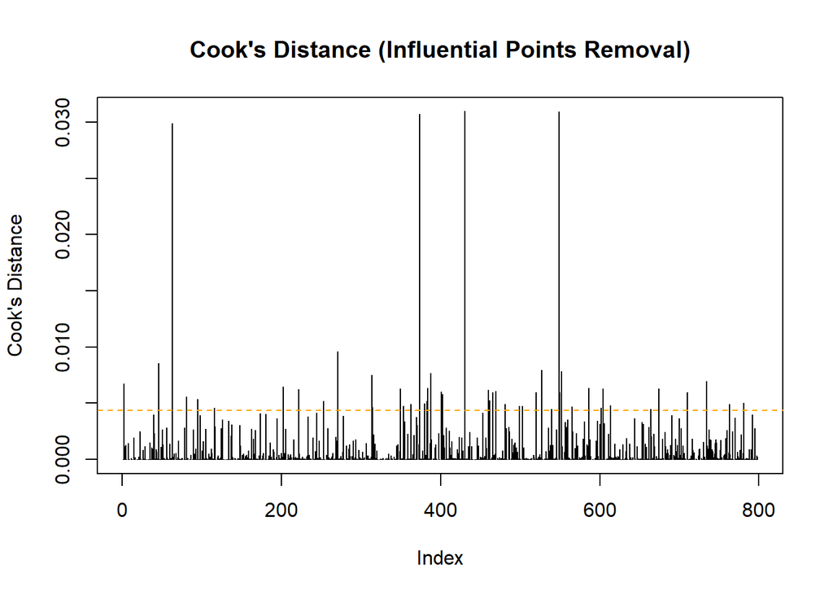

```r
# Plot For Influential Points Check
plot(cooks.distance(iprm), type = "h", main = "Cook's Distance (Influential Points Removal)", ylab = "Cook's Distance")
abline(h = cookst, col = "orange", lty = 2)
```

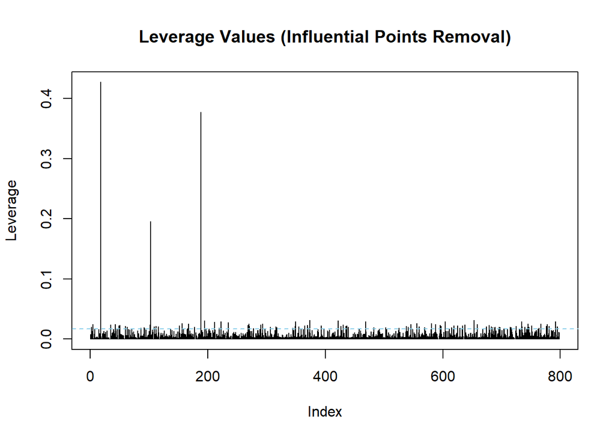

```r
plot(hatvalues(iprm), type = "h", main = "Leverage Values (Influential Points Removal)", ylab = "Leverage")
abline(h = levt, col = "skyblue", lty = 2)
```

The removal of influential data points flagged by Cook’s Distance and leverage values significantly improved the model’s performance. The variable LogRestingBP showed a p-value of 0.0865, indicating it approached significance and may contribute to predicting heart disease. Other variables such as Age, Cholesterol, and Sex (Male) remained highly significant, with p-values of 6.47×10−10, 0.002340, and 1.00×10−13, respectively. The categorical variable Chest Pain Type (ATA and NAP) also maintained its strong, protective effects, with highly significant p-values less than 2×10−16. However, ChestPainTypeTA became insignificant, with a p-value of 0.9803, likely due to reduced influence from outliers.

The model fit improved considerably after the removal of influential points, with the residual deviance dropping to 584.14 and the AIC to 600.14. These metrics indicate a more accurate and reliable model, demonstrating the importance of addressing influential points for robust predictions.

Improvements and Remaining Limitations:

After removing influential points, the model fit improved significantly (residual deviance: 584.14, AIC: 600.14), with predictors showing clearer significance. However, ChestPainTypeTA became insignificant (p=0.9803), indicating unresolved data issues or complexities. While the improved fit enhances reliability, the reduced sample size may limit generalizability. Further investigation of ChestPainTypeTA is recommended.

## Future Analysis Recommendation

While logistic regression provides a straightforward and interpretable model for predicting heart disease risk, other modeling techniques could offer additional insights or improve model robustness. For instance, Ridge Regression and Lasso Regression can help mitigate multicollinearity by adding regularization, making the model less sensitive to small fluctuations in the data. Additionally, Random Forests or Support Vector Machines (SVM) could be explored to capture non-linear relationships in the predictors. Future work could involve testing these models to assess whether they improve prediction accuracy or offer additional interpretive insights.